# Prosper Loans DB. Data Analysis and Visualisation.

Started: 28/04/2019  
Last Update: 13/05/2018  
Eudald Escribà [GitHub](https://github.com/eudald-escriba)

## Investigation Overview

The main purpose of this project is to summarize the characteristics of variables that can affect the loan status and to get some ideas about the relationships among multiple variables using summary statistics and data visualizations.

## Dataset Overview

This project is on a data set from Prosper, which is America’s first marketplace lending platform, with over $7 billion in funded loans. This data set contains 113,937 loans with 81 variables on each loan, including loan amount, borrower rate (or interest rate), current loan status, borrower income, borrower employment status, borrower credit history, and the latest payment information. As well, there is a dictionary with all the terms used in this context. https://docs.google.com/spreadsheets/d/1gDyi_L4UvIrLTEC6Wri5nbaMmkGmLQBk-Yx3z0XDEtI/edit#gid=0

### **4. Univariate Exploration**

#### **Which are the States where more loans have been counted?**

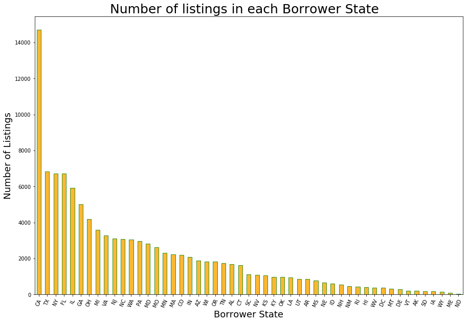

```python
plt.figure(figsize=[15, 10])
loan_data['BorrowerState'].value_counts().plot(kind='bar', color='orange',alpha=0.8,edgecolor='green')
plt.title('Number of listings in each Borrower State  ', fontsize=25);
plt.xlabel('Borrower State', fontsize=18, color='black' );
plt.xticks(rotation=65);
plt.ylabel('Number of Listings', fontsize=18, color='black');
```

> The highest listing counts in CA, TX, NY, FL and the least in WY, ME, ND. This appear in concordance with the population of the states.

#### **Which are the most typicall term to return the money?**

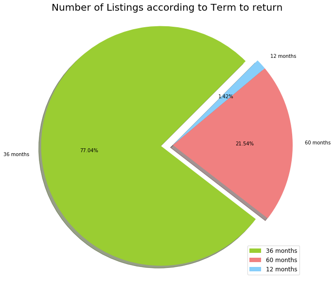

```python
plt.figure(figsize=[10,10])
# Pie chart, where the slices will be ordered and plotted counter-clockwise:
labels = '36 months', '60 months', '12 months'
sizes = loan_data['Term'].value_counts()
colors=['yellowgreen', 'lightcoral', 'lightskyblue']
explode = (0.1, 0, 0)


plt.pie(sizes, explode=explode,colors=colors,  labels=labels, autopct='%1.2f%%',
        shadow=True, startangle=45)
plt.axis('equal')  # Equal aspect ratio ensures that pie is drawn as a circle.
plt.legend( labels,fontsize=12, loc=4);
plt.title('Number of Listings according to Term to return', fontsize=20);
plt.show()
```

> The most frequent accepted return term is 36 months. Three out of four loans are returned in 3 years.

#### **Which is the evolution of the number of listings per year?**

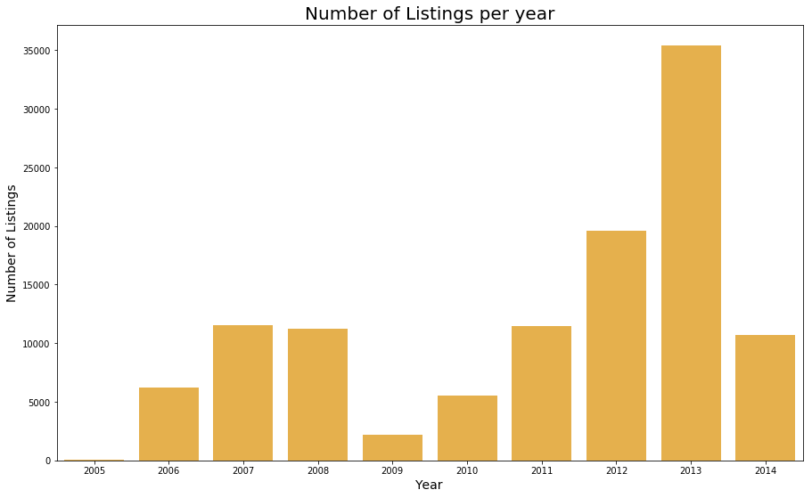

```python
plt.figure(figsize=[15,9])
sb.countplot(x="year", data=loan_data, color='orange', alpha=0.8)
plt.title('Number of Listings per year',fontsize=20)
plt.xlabel('Year',fontsize=14)
plt.ylabel('Number of Listings',fontsize=14)
plt.show()
```

> The data shows how the number of loans plummets in 2009 and progressively (perhaps due to the policies put in place after the crisis) begins to rise until reaching a maximum point in 2013.

#### **Is thera a month when loans count is higher? And lower?**

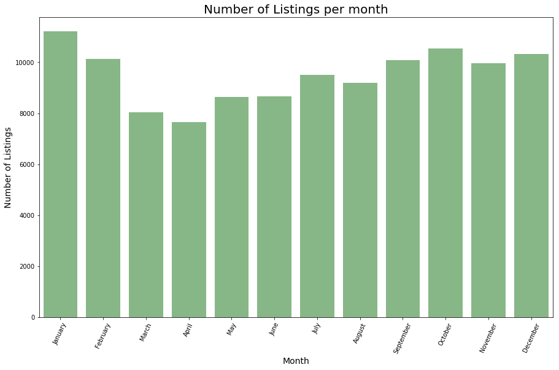

```python
month_order=['January', 'February', 'March' ,'April','May','June','July','August','September','October',
'November', 'December']
plt.figure(figsize=[15,9])
sb.countplot(x="month", data=loan_data, color='green', order=month_order, alpha=0.5);
plt.title('Number of Listings per month',fontsize=20);

plt.xlabel('Month',fontsize=14);
plt.ylabel('Number of Listings',fontsize=14);
plt.xticks(rotation=65);
plt.show()
```

> Data show that around May start an ascending period until January when start declining until May.

### **5. Bivariate Exploration**

#### **Is there a difference in the Principal Borrowed depending on the Income Range?**

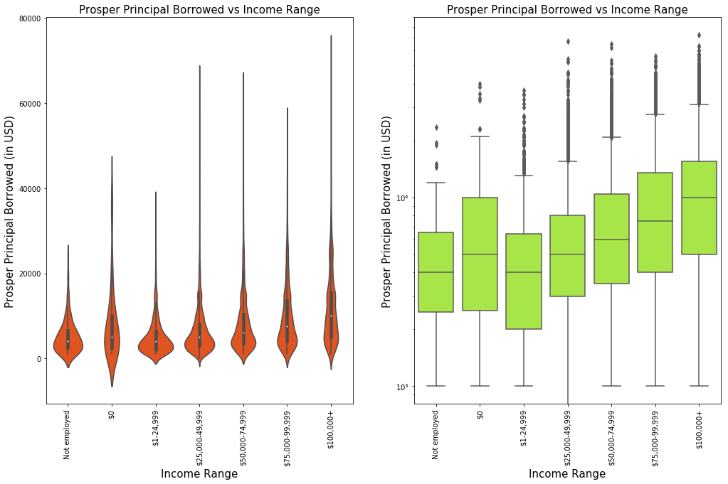

```python
new_order=['Not employed', '$0', '$1-24,999', '$25,000-49,999', '$50,000-74,999', '$75,000-99,999', '$100,000+']

figure=plt.figure(figsize=[17,10]);


plt.subplot(1, 2, 1)
sb.violinplot(data=loan_data, x='IncomeRange', y='ProsperPrincipalBorrowed' , color='orangered', boxprops=dict(alpha=.3), order= new_order);
plt.xticks(rotation=90);

plt.ylabel('Prosper Principal Borrowed (in USD)', fontsize=15)
plt.xlabel('Income Range', fontsize=15)
plt.title('Prosper Principal Borrowed vs Income Range', fontsize=15);
plt.subplot(1, 2, 2)

# scale the y axis with log to analyze more accurately
sb.boxplot(data=loan_data, x='IncomeRange', y='ProsperPrincipalBorrowed', color='greenyellow', order= new_order);
plt.yscale('log')

plt.xticks(rotation=90);
plt.ylabel('Prosper Principal Borrowed (in USD)', fontsize=15)
plt.xlabel('Income Range', fontsize=15)
plt.title('Prosper Principal Borrowed vs Income Range', fontsize=15);
```

> The insights from the both graphs show how the more the income range the more the principal amount borrowed. The 0 dollar income category doesn't follow the rule. Violin plot show as well how the more the income range the more the range of principal.

#### **Can people with deliquences borrow money?**

[figure not shown]

```python
#style
figure=plt.figure(figsize=[12,10]);
plt.xlabel('Delinquencies in the last 7 Years', fontsize=15)
plt.ylabel('Prosper Principal Borrowed', fontsize=15)
plt.title('Delinquencies in the last 7 Years vs. Prosper Principal Borrowed', fontsize=18)


# remove the null entries
loan_data_sub = loan_data.loc[loan_data.DelinquenciesLast7Years.notnull()]
loan_data_sub2 = loan_data_sub.loc[loan_data.ProsperPrincipalBorrowed.notnull()]


# plots the hist2d graph
plt.hist2d(data=loan_data_sub2, x='ProsperPrincipalBorrowed', y='DelinquenciesLast7Years', cmin=100, cmap='summer_r');
plt.colorbar()
```

> The graph allows us to see that the customers with the highest number of deliquesions in the last 7 years correspond to clients with a low principal. It can also be seen that for a medium/high number of delicuences there is no loan. The graph show that high loans are correlated to a low number of delicuences.

### **6. Multivariate Exploration**

#### **Is the Borrower Rate time evolution related to the term to return the money?**

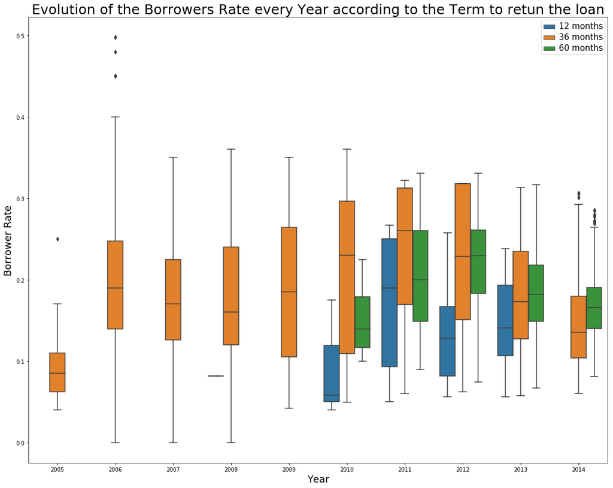

```python
figure=plt.figure(figsize=[19,15]);

plot = sb.boxplot(x='year', y='BorrowerRate' , data=loan_data, hue='Term',)

leg = plot.get_legend()
leg.set_title("")
labs = leg.texts
labs[0].set_text('12 months')
labs[1].set_text('36 months')
labs[2].set_text('60 months')
labs[0].set_fontsize(15)
labs[1].set_fontsize(15)
labs[2].set_fontsize(15)
plot.axes.xaxis.label.set_fontsize(18)
plot.axes.xaxis.label.set_text('Year')
plot.axes.yaxis.label.set_fontsize(18)
plot.axes.yaxis.label.set_text('Borrower Rate')
plt.title('Evolution of the Borrowers Rate every Year according to the Term to retun the loan', fontsize=25);
```